# Assignment 5

Eric Zhou

2022-11-2

# **Apprentice**

## Problem 1

```r
data <- read.csv('WA-wildfires.csv')
```

#### **Part a**: 20 x 4 matrix. Rows are for the different fire seasons and columns are season, total_fires, acres_burned, and rainier_snow

```r
dim(data)
```

```
## [1] 20  4
```

```r
head(data)
```

```
##   season total_fires acres_burned rainier_snow
## 1   2002        1285        92742          837
## 2   2003        1373       200517          575
## 3   2004        1674        92617          674
## 4   2005         998       185748          409
## 5   2006        1579       410060          758
## 6   2007        1268       214925          665
```

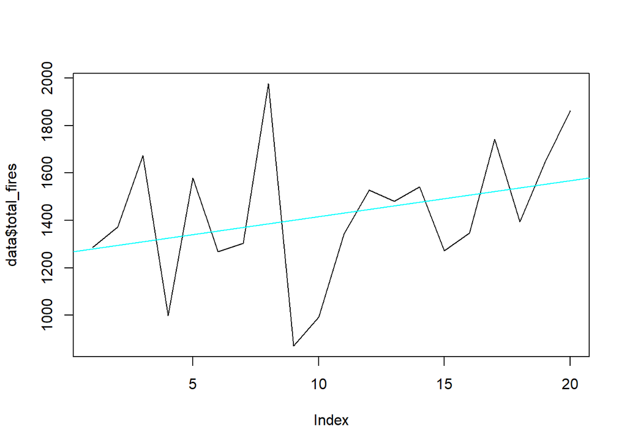

```r
plot(data$total_fires, type='l')
abline(lm(data$total_fires ~ seq(1:length(data$total_fires))), col="cyan")
```

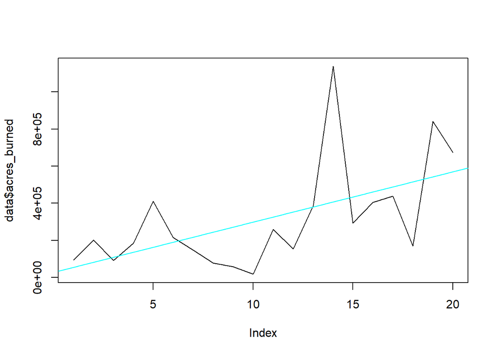

```r
plot(data$acres_burned, type='l')
abline(lm(data$acres_burned ~ seq(1:length(data$acres_burned))), col="cyan")
```

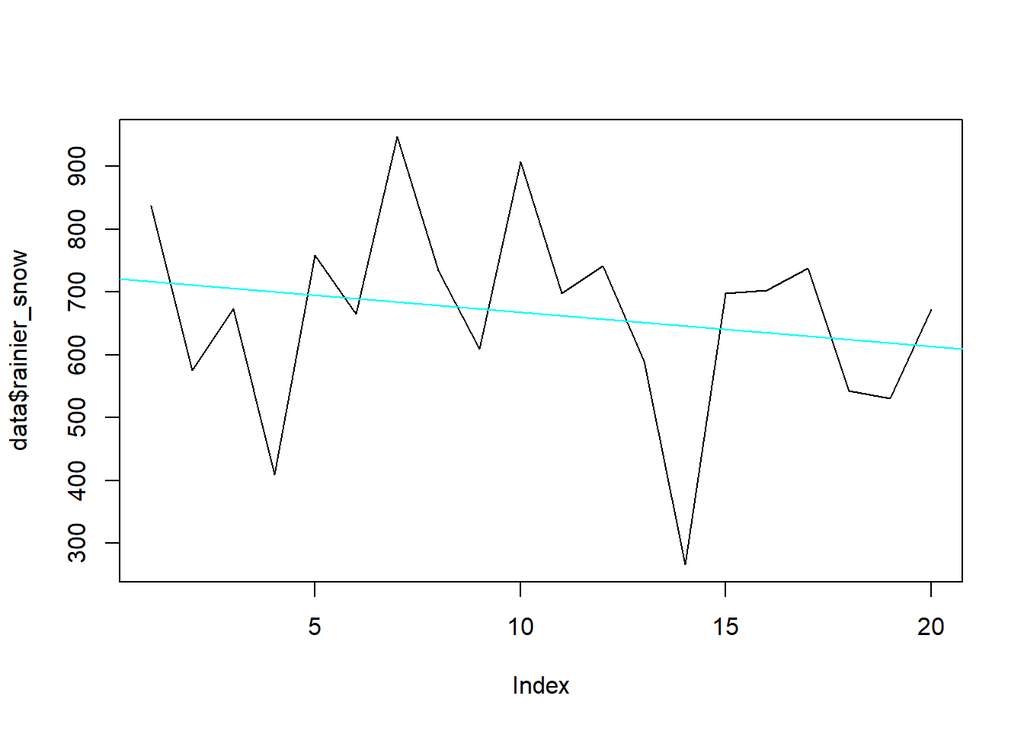

```r
plot(data$rainier_snow, type='l')
abline(lm(data$rainier_snow ~ seq(1:length(data$rainier_snow))), col="cyan")
```

```r
sd(data$total_fires)
```

```
## [1] 284.1692
```

```r
mean(data$total_fires)
```

```
## [1] 1423.65
```

```r
sd(data$acres_burned)
```

```
## [1] 285700.1
```

```r
mean(data$acres_burned)
```

```
## [1] 312764.8
```

```r
sd(data$rainier_snow)
```

```
## [1] 157.3873
```

```r
mean(data$rainier_snow)
```

```
## [1] 664.7
```

#### **Part c**: There were 28473 total fires and 6255295 total acres burned

```r
sum(data$total_fires)
```

```
## [1] 28473
```

```r
sum(data$acres_burned)
```

```
## [1] 6255295
```

#### **Part d**: Mean is 664.7, standard deviation is 157.3872529, using mean +- 2 standard deviation (~95% of the data) so 349.9255 to 979.4745. The only season outside of those bounds is 2015

```r
snowmean <- mean(data$rainier_snow)
snowdeviation <- sd(data$rainier_snow)
snowmean
```

```
## [1] 664.7
```

```r
snowdeviation
```

```
## [1] 157.3873
```

```r
lbound <- snowmean - 2 * snowdeviation
rbound <- snowmean + 2 * snowdeviation
lbound
```

```
## [1] 349.9255
```

```r
rbound
```

```
## [1] 979.4745
```

```r
data$season[data$rainier_snow < lbound | data$rainier_snow > rbound]
```

```
## [1] 2015
```

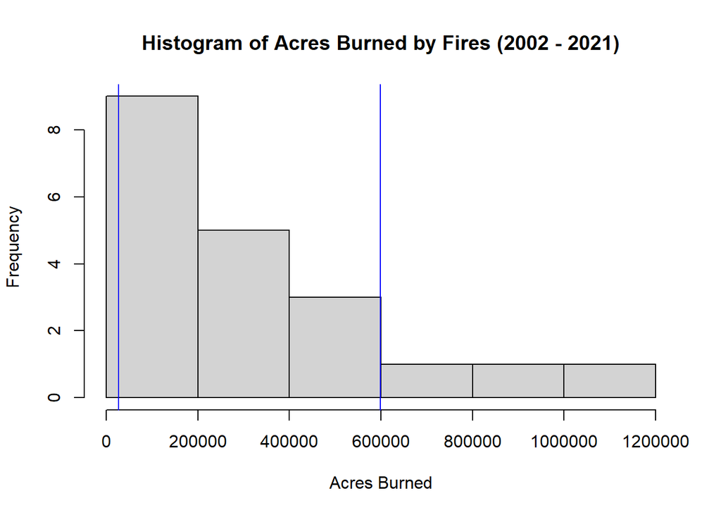

```r
hist(data$acres_burned, breaks=5, xlim = c(0, 1200000), xlab="Acres Burned", main="Histogram of Acres Burned by Fires (2002 - 2021)")
abline(v=mean(data$acres_burned) - sd(data$acres_burned), col="blue")
abline(v=mean(data$acres_burned) + sd(data$acres_burned), col="blue")
```

#### **Part f**: There doesn’t seem to be much of a pattern, not really trending positive or negative with just a blob of points in the center. It definitely does not look linear but I don’t really think any other function would fit this either. Definitely a very weak correlation, the correlation is only about -0.02 so very close to 0. In the graph, the very left and right on the x-axis, or the extremes of snowfall, don’t have many values and include values that are close to the mean but also ones that are relatively far. In the middle, other than the 1 outlier at the very bottom, it seems that the variance increases as snowfall increases.

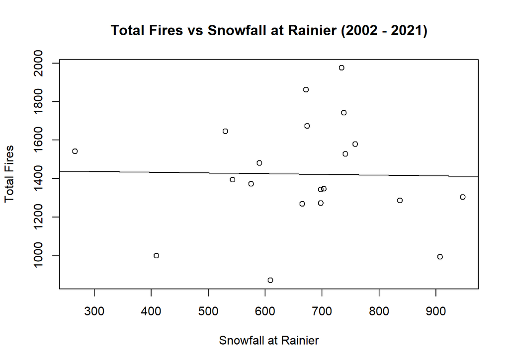

```r
plot(data$rainier_snow, data$total_fires, xlab="Snowfall at Rainier", ylab="Total Fires", main="Total Fires vs Snowfall at Rainier (2002 - 2021)")
abline(lm(data$total_fires~data$rainier_snow))
```

```r
cor(data$total_fires, data$rainier_snow)
```

```
## [1] -0.01953722
```

#### **Part g**: There were 1674 total fires in 2004

```r
data$total_fires[data$season == 2004]
```

```
## [1] 1674
```

#### **Part h**: 9 seasons had fewer

```r
sum(data$acres_burned < 200000)
```

```
## [1] 9
```

#### **Part i**: 85% had more

```r
sum(data$total_fires > 1000)/length(data$total_fires)
```

```
## [1] 0.85
```

# **Master**

## Problem 2

#### **Part a**: Most fires was 2009, 2021, and 2018. Least snowfall was 2015, 2005, and 2020

```r
data[order(data$total_fires,decreasing=TRUE),]$season[1:3]
```

```
## [1] 2009 2021 2018
```

```r
data[order(data$rainier_snow),]$season[1:3]
```

```
## [1] 2015 2005 2020
```

#### **Part b**: The mean is 487168.8 acres, median is 293744.5 acres

```r
mean(data$acres_burned[data$rainier_snow < 600])
```

```
## [1] 487168.8
```

```r
median(data$acres_burned[data$rainier_snow < 600])
```

```
## [1] 293744.5
```

#### **Part c**: 1976 total fires

```r
max(data$total_fires[data$rainier_snow > mean(data$rainier_snow)])
```

```
## [1] 1976
```

#### **Part d**: Median is 698

```r
median(data$rainier_snow[data$total_fires > 1200])
```

```
## [1] 698
```

#### **Part e**: Concentrated around 200 but there’s a super high outlier and the upper whisker is a lot longer than lower.

```r
mean_acre <- data$acres_burned / data$total_fires
mean_acre
```

```
##  [1]  72.17276 146.04297  55.32676 186.12024 259.69601 169.49921 113.01919
##  [8]  39.09413  65.31034  17.60322 193.38748  99.93648 261.46757 738.26347
## [15] 230.90959 300.31426 251.76879 121.76614 511.76792 361.90123
```

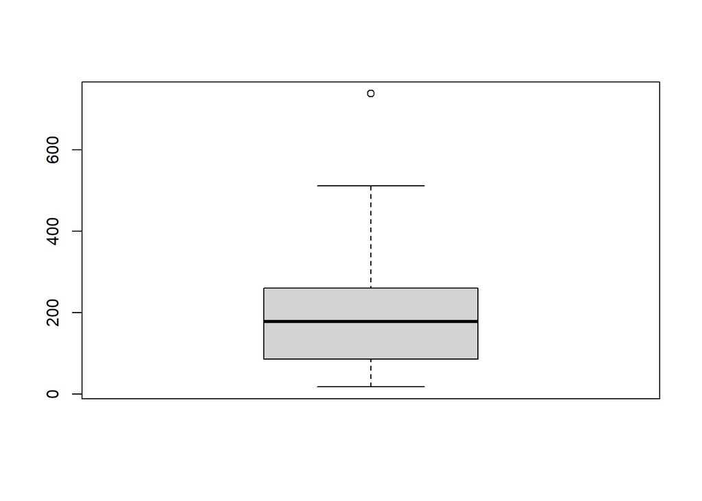

```r
boxplot(mean_acre)
```

#### **Part f**: Acres burned has a correlation of around 0.41 and -0.58 for total fires and rainier snowfall respectively. You can definitely tell the trend and correlation in the graph and technically, snow has a stronger relationship because the absolute value of the correlation is higher so it is more indicative of the value. However, we can also definitely see that there is still a lot of variation and error in the linear model so that’s why the absolute value o the correlation is still below 0.6, which is not very good for proportional relationships. I think that a positive relationship between acres burned and total fires definitely makes sense because more fires would most likley mean thatmore area was burned. The negative correlation between snow and acres burned also makes some sense since cold and rainy would mean snow but also less burning for fires.

```r
cor(data$acres_burned, data$total_fires)
```

```
## [1] 0.4083249
```

```r
cor(data$acres_burned, data$rainier_snow)
```

```
## [1] -0.5809165
```

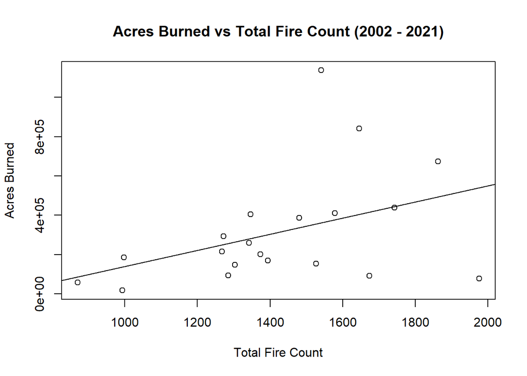

```r
plot(data$total_fires, data$acres_burned, xlab="Total Fire Count", ylab="Acres Burned", main="Acres Burned vs Total Fire Count (2002 - 2021)")
abline(lm(data$acres_burned ~ data$total_fires))
```

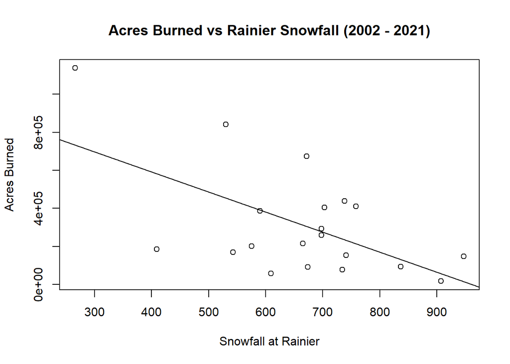

```r
plot(data$rainier_snow, data$acres_burned, xlab="Snowfall at Rainier", ylab="Acres Burned", main="Acres Burned vs Rainier Snowfall (2002 - 2021)")
abline(lm(data$acres_burned ~ data$rainier_snow))
```

# **Wizard**

## Problem 3

#### **Part a**: Yes, 2004, 2006, 2009, 2013, 2014, 2018, 2020, and 2021

```r
data$season[data$total_fires > 1400 & data$acres_burned < 1e6]
```

```
## [1] 2004 2006 2009 2013 2014 2018 2020 2021
```

#### **Part b**: Yes, 2006, 2017, 2018, and 2021

```r
data$season[data$rainier_snow > 650 & data$acres_burned > 375000]
```

```
## [1] 2006 2017 2018 2021
```

#### **Part c**: What is the mean inches of snowfall for seasons where average fire size was higher than 500? Answer is 398.

```r
mean(data$rainier_snow[mean_acre > 500])
```

```
## [1] 398
```

#### **Part d**: Median snowfall is 686. There is a difference. When the snowfall was blow the median, the median acres burned of the 2 sets were fairly close but the upper 50% of the acres burned is way more spread out and way higher than the upper 50% of the acres burned where snowfall was above median

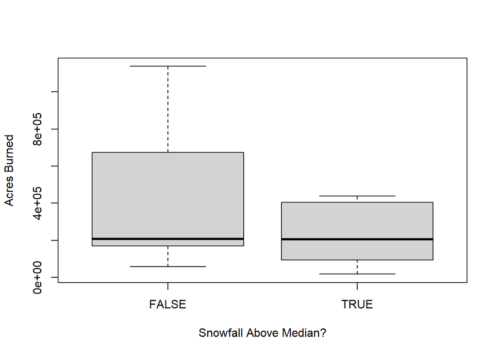

```r
data$above_med <- data$rainier_snow > median(data$rainier_snow)
boxplot(data$acres_burned ~ data$above_med, xlab="Snowfall Above Median?", ylab="Acres Burned")
```

#### **Part e**: I ignored leap years and rounded to the closest day

```r
data$kc_aq <- c(NA, NA, NA, 0.696, 0.734, NA, 0.512, 0.745, 0.877, 0.866, 0.863, 0.605, 0.723, 0.584, 0.822, 0.729, 0.732, 0.767, 0.811, 0.841)
mid_aq <- round((1 - data$kc_aq) * 365)
mid_aq
```

```
##  [1]  NA  NA  NA 111  97  NA 178  93  45  49  50 144 101 152  65  99  98  85  69
## [20]  58
```

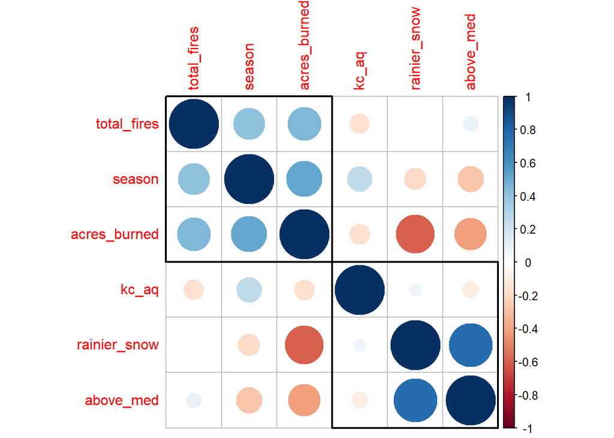

```r
library(corrplot) #for correlation plots
corrs <- cor(na.omit(data))
corrplot(corrs, order = 'hclust', addrect = 2, )
```

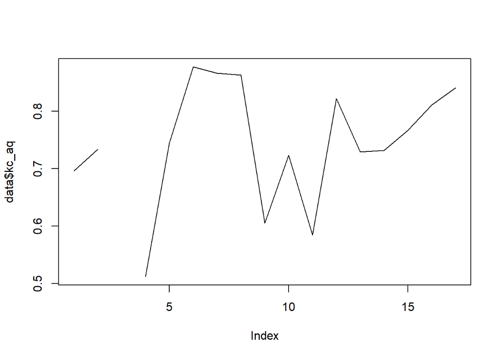

```r
data <- data[4:length(data$season),]
plot(data$kc_aq, type='l')
```

```r
cor(data$kc_aq, data$total_fires, use="complete.obs")
```

```
## [1] -0.1638893
```

```r
cor(data$kc_aq, data$rainier_snow, use="complete.obs")
```

```
## [1] 0.06223287
```

```r
cor(data$kc_aq, data$acres_burned, use="complete.obs")
```

```
## [1] -0.1674022
```

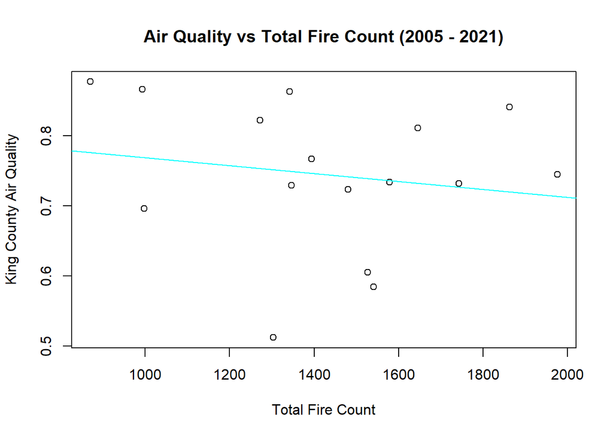

```r
plot(data$total_fires, data$kc_aq, xlab="Total Fire Count", ylab="King County Air Quality", main="Air Quality vs Total Fire Count (2005 - 2021)")
abline(lm(data$kc_aq ~ data$total_fires), col="cyan")
```

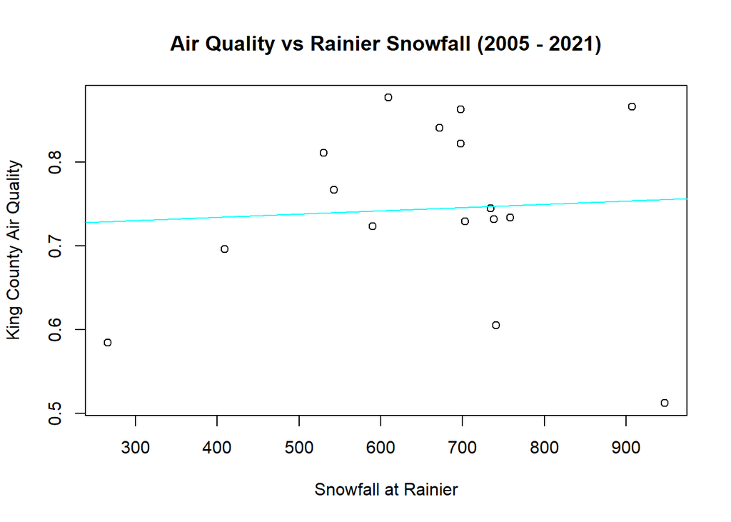

```r
plot(data$rainier_snow, data$kc_aq, xlab="Snowfall at Rainier", ylab="King County Air Quality", main="Air Quality vs Rainier Snowfall (2005 - 2021)")
abline(lm(data$kc_aq ~ data$rainier_snow), col="cyan")
```

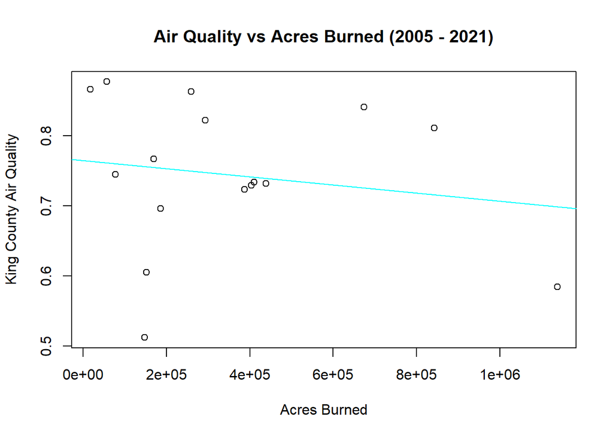

```r
plot(data$acres_burned, data$kc_aq, xlab="Acres Burned", ylab="King County Air Quality", main="Air Quality vs Acres Burned (2005 - 2021)")
abline(lm(data$kc_aq ~ data$acres_burned), col="cyan")
```